# Final

### Craig’s Questions:

Variables: yearBuilt, bathroomcnt, airconditioningtypeid, regionIDCity, fireplacecnt

1. What is the relationship between bathroomcnt and fireplacecnt
2. What is the relationship between yearbuilt and airconditioningtypeid
3. What is the relationship between firepalcecnt and yearbuilt

In modern architecture, fire places are not very common place, but do exist especially in nicer homes. In older architecture, they are more common for both stylistic and actual warmth purposes. Bathrooms are required for all homes to my knowledge, and having more of them is indicative of either a multi-family home or a nicer home. I would like to compare them and ensure these variables aren’t dependent and that they are not just both indicative of similar properties.

> __ Numeric vs Numeric__

```r
CraigsHousing = HousingOriginal
#fireplacecnt had to have nas replaced with 0s for the plot
CraigsHousing$fireplacecnt = CraigsHousing$fireplacecnt %>% replace_na(0)
CraigsHousing[CraigsHousing$bathroomcnt > 10, ] %>% count()
```

```
##     n
## 1 219
```

```r
CraigsHousing[CraigsHousing$bathroomcnt < CraigsHousing$fireplacecnt, ] %>% count()
```

```
##     n
## 1 616
```

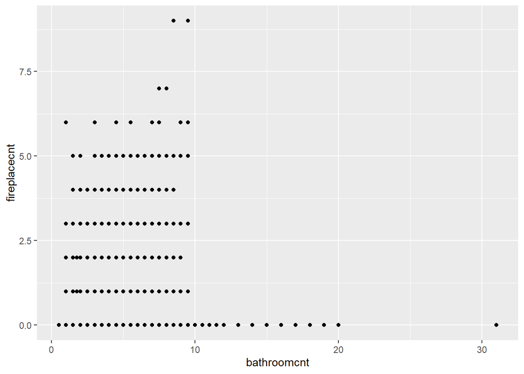

```r
CraigsHousing %>% ggplot(aes(x=bathroomcnt, y=fireplacecnt)) + geom_point()
```

```r
cor(CraigsHousing$bathroomcnt, CraigsHousing$fireplacecnt)
```

```
## [1] 0.08695065
```

> **Numeric vs categorical**

Air conditioning is a rather recent invention compared to some of these houses. With that in mind, I am quite curious what air conditioning systems are most common for different eras

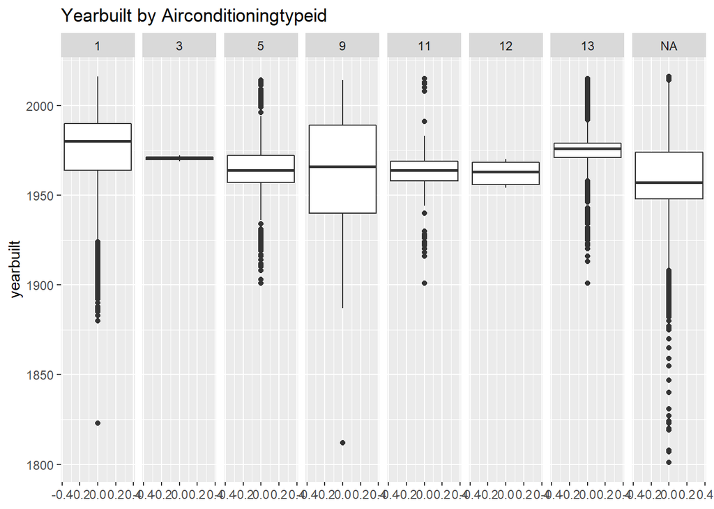

```r
CraigsHousing %>% ggplot(aes(y=yearbuilt)) +
  geom_boxplot() +
  facet_grid(~airconditioningtypeid) +
  ggtitle("Yearbuilt by Airconditioningtypeid")
```

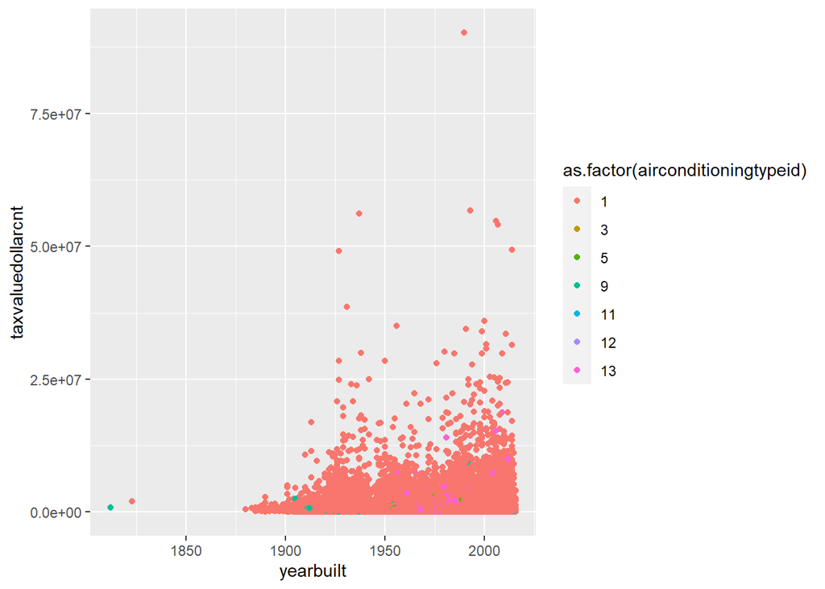

```r
filter(CraigsHousing, airconditioningtypeid > 0) %>%
  ggplot(aes(y=taxvaluedollarcnt,
             x=yearbuilt,
             color=as.factor(airconditioningtypeid))) +
  geom_point()
```

1 Central, 3 Evaporative Cooler, 5 None, 9 Refrigeration, 11 Wall Unit, 12 Window Unit, 13 Yes

We will also explore the relationship between fireplacecnt and yearbuilt. As houses get newer, I believe they have less fireplaces.

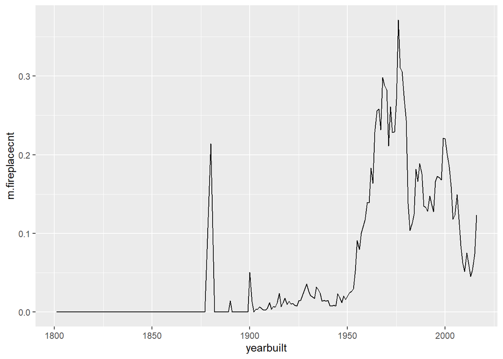

```r
CraigsHousing.byYear = CraigsHousing %>% group_by(yearbuilt) %>%
  summarize(
    m.fireplacecnt = mean(fireplacecnt, na.rm=TRUE)
  )
CraigsHousing.byYear %>% ggplot(aes(x=yearbuilt, y=m.fireplacecnt)) + geom_line()
```

This data in a way confirms my idea that newer houses have less fireplaces, but they seem to come back in trends, such as around 200, and 2015 or so. This graph did definitely not look like I thought it would.

### Ngoc’s Questions:

Ngoc’s variables: basementsqft, finishedsquarefeet15, landtaxvaluedollarcnt, typeconstructiontypeid, garagetotalsqft

1. What is the relationship between basementsqft, and garagetotalsqft. My expectation for the relationship: I would think they have positive correlation relationship, and larger basement area will have larger garage area.
2. What is the relationship between finishedsquarefeet15 and typeconstructiontypeid

3. What is the relationship between airconditioningtypeid and typeconstructiontypeid

My expectation: I would like to see if there is any type of construction has what’s type of air conditioner.

> **Numeric vs Numeric**

```r
NgocHousing = HousingOriginal

# I wanna see how many houses have garage larger than their basement
NgocHousing[NgocHousing$basementsqft< NgocHousing$garagetotalsqft, ] %>% count()
```

```
##        n
## 1 999720
```

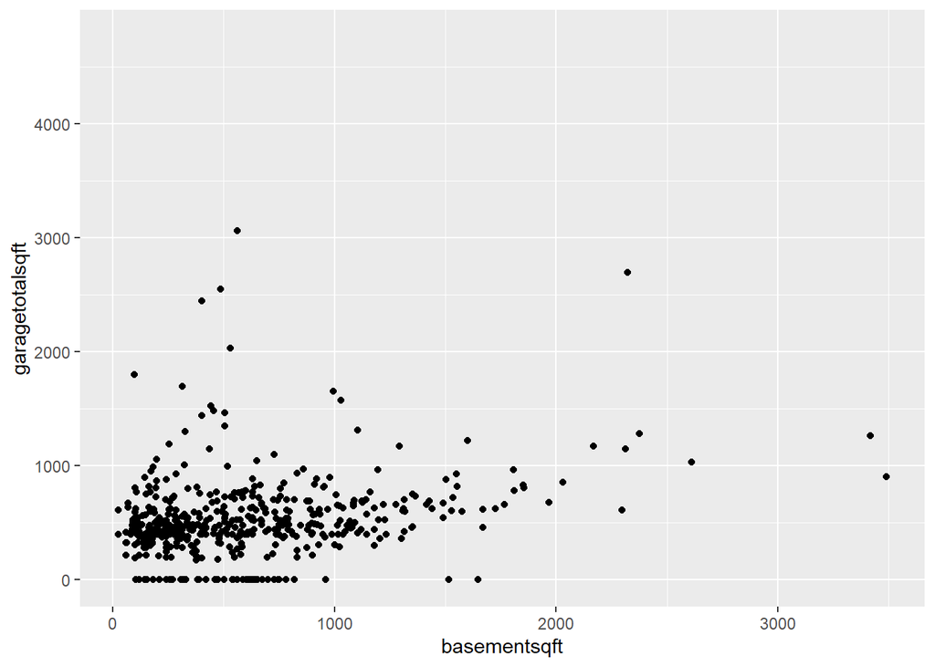

```r
NgocHousing %>% ggplot(aes(x=basementsqft, y=garagetotalsqft)) + geom_point()
```

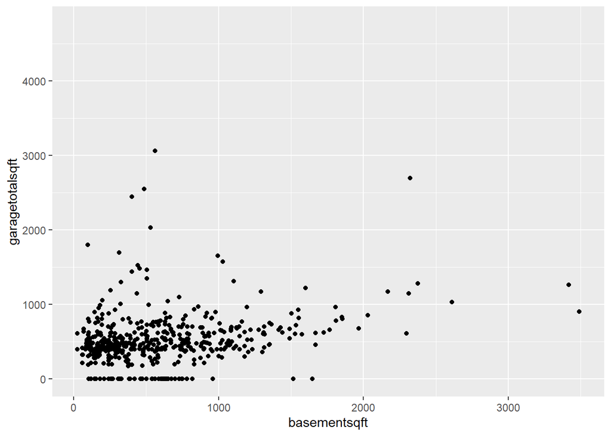

```r
NgocHousing %>% ggplot(aes(x=basementsqft, y=garagetotalsqft)) + geom_point()
```

```r
cor(NgocHousing$basementsqft, NgocHousing$garagetotalsqft)
```

```
## [1] NA
```

Now let’s adding one more variable

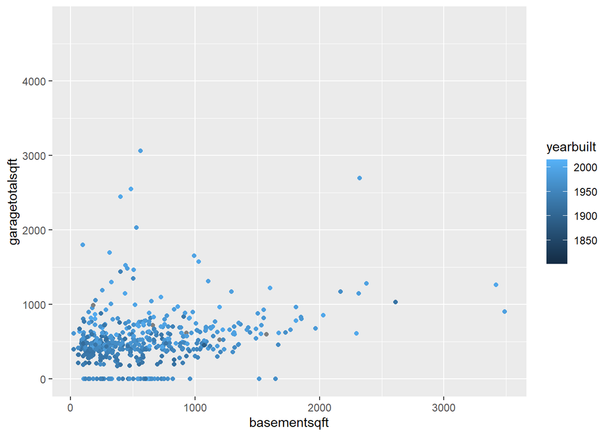

```r
#adding one more variable yearbuilt
NgocHousing %>% ggplot(aes(x=basementsqft, y=garagetotalsqft,color = yearbuilt)) + geom_point()
```

I would conlucde that the houses that built after 2000 tend to have larger basement and also have some significant garage area even though it has 0 or little are of basement. This can be explain either those houses in California or it’s an apartment or the basement was not finished.

> **Numeric vs Categorical**

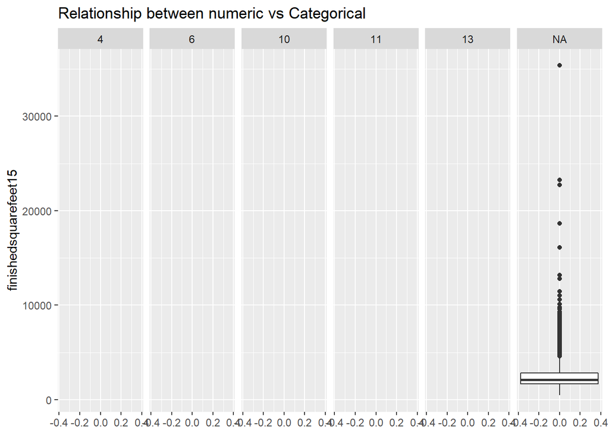

```r
NgocHousing %>% ggplot(aes(y= finishedsquarefeet15)) + geom_boxplot() + facet_grid(~typeconstructiontypeid) + ggtitle("Relationship between numeric vs Categorical")
```

Now adding one more variable: yearbuilt

[figure not shown]

```r
#adding one more variable

NgocHousing %>% ggplot(aes(y= finishedsquarefeet15)) + geom_boxplot() + facet_grid(~typeconstructiontypeid + yearbuilt) + ggtitle("Relationship between numeric vs Categorical")
```

> **Categorical vs Categorical**

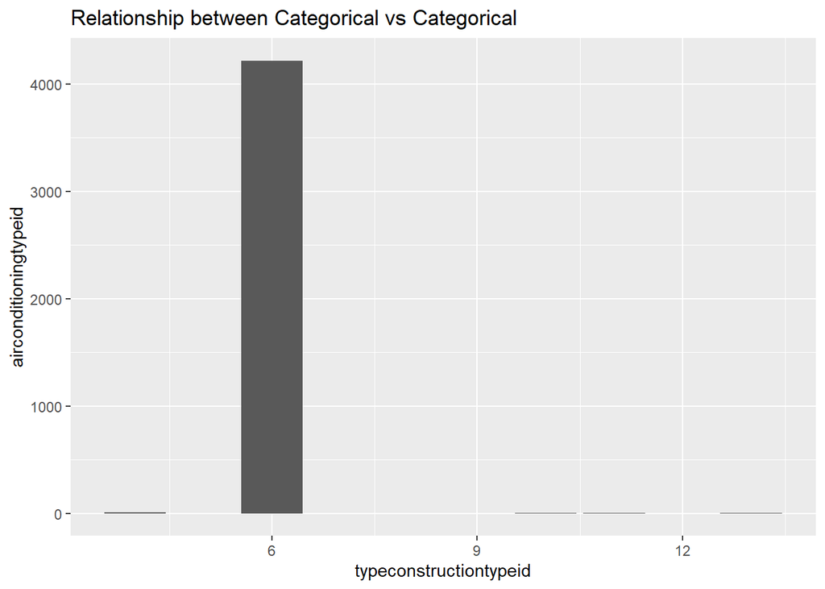

```r
NgocHousing %>% ggplot(aes(x=typeconstructiontypeid, y= airconditioningtypeid)) + geom_bar(stat = "identity") + ggtitle("Relationship between Categorical vs Categorical")
```

My expectation is not met in this case since I could not see the relationship between them due to missing value of typeconstructiontypeid.

Now let’s add one more variable: yearbuilt

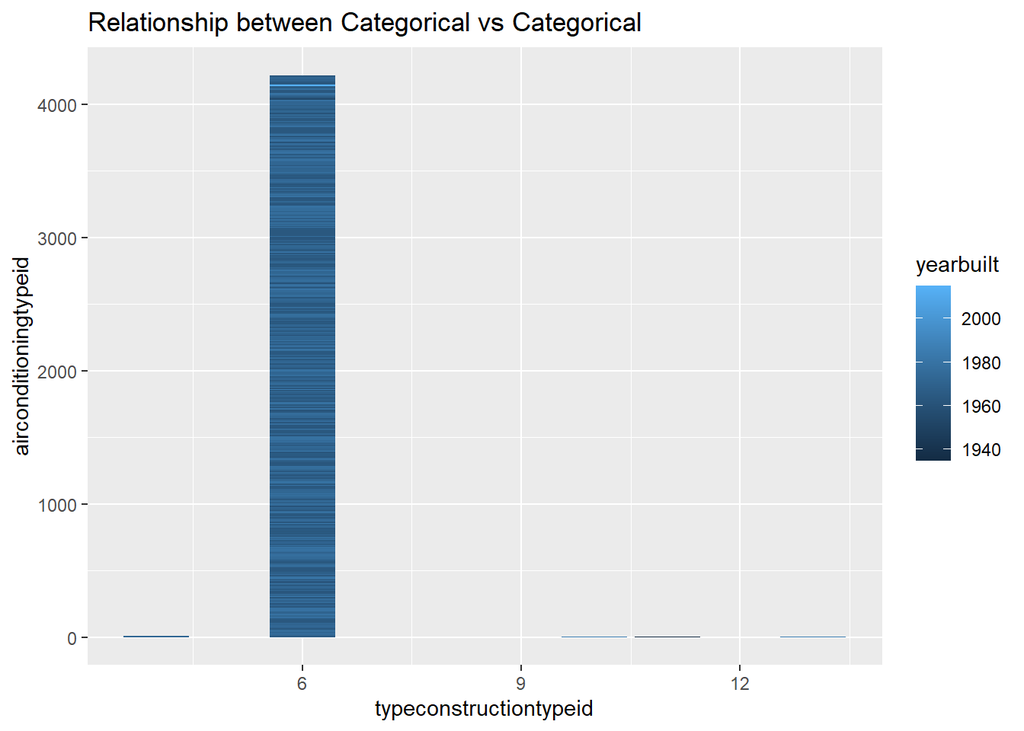

```r
NgocHousing %>% ggplot(aes(x=typeconstructiontypeid, y= airconditioningtypeid, fill = yearbuilt)) + geom_bar(stat = "identity") + ggtitle("Relationship between Categorical vs Categorical")
```

### Linear regression

First we check the explanatory variables against the response.

```r
regressionData = HousingOriginal %>% select(taxvaluedollarcnt, yearbuilt, bathroomcnt)
res <- cor(regressionData)
round(res, 2)
```

```
##                   taxvaluedollarcnt yearbuilt bathroomcnt
## taxvaluedollarcnt              1.00        NA        0.46
## yearbuilt                        NA         1          NA
## bathroomcnt                    0.46        NA        1.00
```

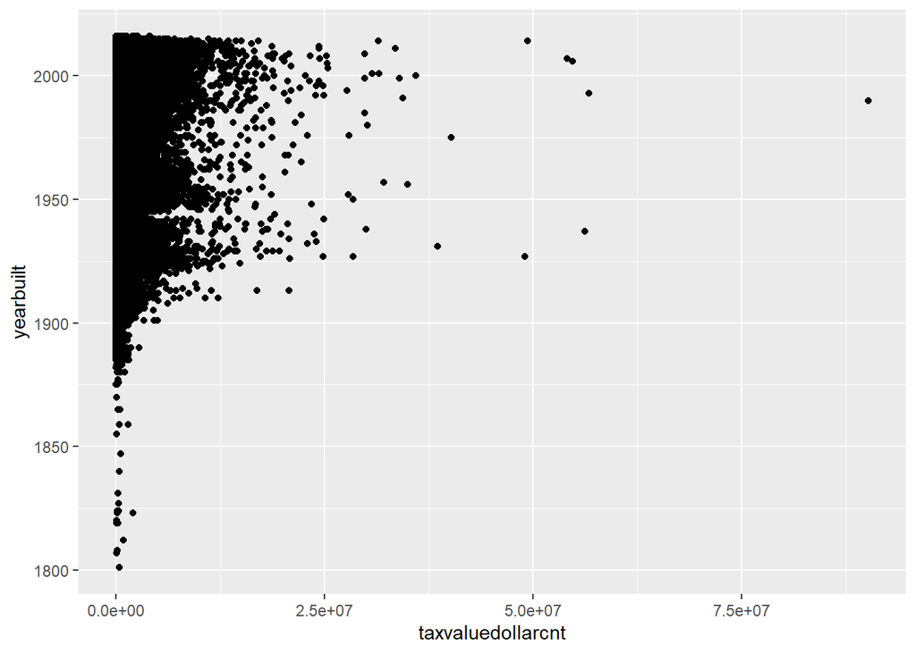

```r
regressionData %>% ggplot(aes(x=taxvaluedollarcnt, y=yearbuilt)) + geom_point()
```

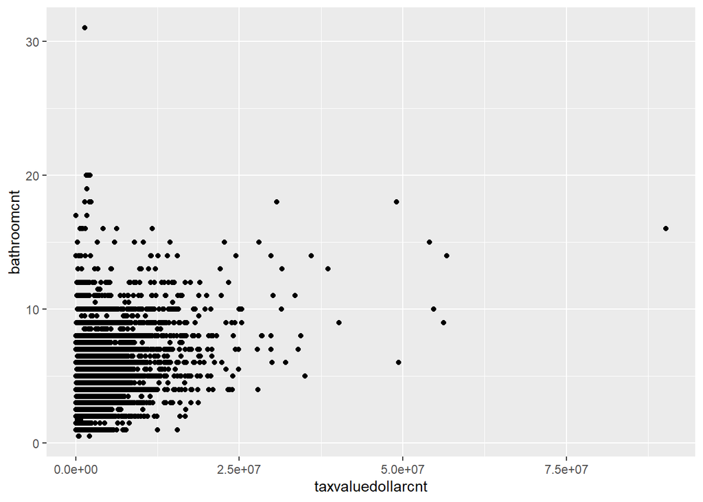

```r
regressionData %>% ggplot(aes(x=taxvaluedollarcnt, y=bathroomcnt)) + geom_point()
```

Next, as practice, we will try a single regression investigating whether using only yearbuilt helps to explain taxvaluedollarcnt.

```r
single.regression <- lm(taxvaluedollarcnt ~ yearbuilt, data = regressionData)

summary(single.regression)
```

```
##
## Call:
## lm(formula = taxvaluedollarcnt ~ yearbuilt, data = regressionData)
##
## Residuals:
##      Min       1Q   Median       3Q      Max
##  -629079  -244483  -108090    72173 89646046
##
## Coefficients:
##               Estimate Std. Error t value Pr(>|t|)
## (Intercept) -7.342e+06  4.967e+04  -147.8   <2e-16 ***
## yearbuilt    3.962e+03  2.528e+01   156.7   <2e-16 ***
## ---
## Signif. codes:  0 '***' 0.001 '**' 0.01 '*' 0.05 '.' 0.1 ' ' 1
##
## Residual standard error: 596900 on 998985 degrees of freedom
##   (1013 observations deleted due to missingness)
## Multiple R-squared:  0.02399,    Adjusted R-squared:  0.02399
## F-statistic: 2.456e+04 on 1 and 998985 DF,  p-value: < 2.2e-16
```

Does this model help to explain taxvaluedollarcnt? Null hypothesis: b1 = 0 Alternative hypothesis: b1 != 0 f statistic: 2.456e+04 p value: <0.0001 Conclusion: we have overwhelimg evidence that using yearbuilt helps to explain the value of taxvaluedollarcnt in the sample. Equation = -7.342e+06 + 3.962e+03*yearbuilt adjusted R^2: 0.02399 This means that using yearbuilt we can explain 2.4% of the variance in taxvaluedollarcnt

With real estate being an interesting and dynamic market a single variable obviously wouldn’t do very well. I was expecting it to perform better though. How about more variables?

```r
multiple.regression <- lm(taxvaluedollarcnt ~ yearbuilt + bathroomcnt, data = regressionData)

summary(multiple.regression)
```

```
##
## Call:
## lm(formula = taxvaluedollarcnt ~ yearbuilt + bathroomcnt, data = regressionData)
##
## Residuals:
##      Min       1Q   Median       3Q      Max
## -7074731  -213694   -44195   126585 85919945
##
## Coefficients:
##              Estimate Std. Error t value Pr(>|t|)
## (Intercept) 615355.83   47575.62   12.93   <2e-16 ***
## yearbuilt     -417.42      24.46  -17.07   <2e-16 ***
## bathroomcnt 280238.92     576.62  486.00   <2e-16 ***
## ---
## Signif. codes:  0 '***' 0.001 '**' 0.01 '*' 0.05 '.' 0.1 ' ' 1
##
## Residual standard error: 536800 on 998984 degrees of freedom
##   (1013 observations deleted due to missingness)
## Multiple R-squared:  0.2106, Adjusted R-squared:  0.2106
## F-statistic: 1.333e+05 on 2 and 998984 DF,  p-value: < 2.2e-16
```

Does this model help to explain taxvaluedollarcnt? Null hypothesis: b1 = b2 = 0 Alternative hypothesis: atleast one of b1, b2 != 0 f statistic: 1.333e+05 p value: <0.0001 Conclusion: we have overwhelimg evidence that using yearbuilt and bathroomcnt help to explain the value of taxvaluedollarcnt in the sample. Equation = 615,355.83 - 417.42 * yearbuilt + 280,238.92 * bathroomcnt adjusted R^2: 0.2106 This means that using yearbuilt and bathroomcnt we can explain 21% of the variance in taxvaluedollarcnt

These results are suspicious. $280k seems like a lot per bathroom, and as houses get newer I would think they get more valuable but that does not appear to be the case. Our R^2 is quite low, but raised dramatically from the single variable.